# White House Visitors - Explorations - By Month

Earl F Glynn

2024-06-13

Also see `Counts` directory created by script `1-WhiteHouse-Visitors-Processing.Rmd` with frequency counts of values of fields.

# 1 Setup

## 1.1

## 1.2 Constants

```r
DATA_RELEASE  <- "2024-06-07"                                              ##### (1/2)
```

```r
RANGE <- "(Jan 2021 - Feb 2024)"                                           ##### (2/2)
```

```r
SOURCE <- "Source: https://www.whitehouse.gov/disclosures/visitor-logs/\n"
stamp  <- paste0("watchdoglab.substack.com\n", format(time.1, "%Y-%m-%d"))
```

For plot scaling

```r
VISITOR_LIMIT <- 100000  # Dec 2022 - all visitors
PVF_LIMIT     <-  20000  # Dec 2022 - POTUS/VPOTUS/FLOTU visitors
```

```r
EXCEL_LIMIT <- 2^20
```

## 1.3 Packages

```r
library(tidyverse)
```

```r
library(lubridate)   # parse_date_time, mdy_hm

library(downloader)  # download
library(tools)       # md5sum
```

I/O

```r
library(readxl)      # read_xlsx
library(readr)       # write_csv
library(writexl)     # write_xlsx
```

Display formatting

```r
library(kableExtra)  # kable_styling
```

```r
#library(IRdisplay)   # display_html (needed in Jupyter notebooks)
```

Graphics

```r
library(RColorBrewer)
library(scales)      # comma, comma_format
```

## 1.4 ggplot theme

[ggplot Themes Gallery](https://www.datanovia.com/en/blog/ggplot-themes-gallery/)

```r
theme_set(theme_minimal() +

            theme(
                   axis.text             = element_text(size =  9),
                   axis.title            = element_text(size = 11),

                   plot.caption          = element_text(size =  10,
                                                        hjust = c(0.0,1.0)),
                   plot.caption.position = "plot",

                   plot.title.position   = "plot",
                   plot.title            = element_text(size = 14),
                   plot.subtitle         = element_text(size = 12),

                   strip.background      = element_rect(fill = "aliceblue"),
                   strip.text            = element_text(size = 14),

                   panel.grid.minor.x    = element_blank(),
                   panel.grid.minor.y    = element_blank()
                 )
         )
```

```r
COLOR_BAR     <- "skyblue"
COLOR_OUTLINE <- "grey80"
```

## 1.5 Helper functions

### 1.5.1 Show

```r
Show <- function(data, caption="", bigMark="",
                 height = NULL, width = NULL, ...)
{
  data                                       |>
  kable("html", caption=caption,
        format.args=list(big.mark=bigMark))  |>
  kable_styling(bootstrap_options=c("striped", "bordered", "condensed"),
                position="left",
                full_width=FALSE, ...)       |>
  scroll_box(height = height, width = width)
}
```

# 2 Read White House Visitor Data

Combined from all reports

```r
wh <-
  read_csv(paste0("White-House-Visitor-Log-Data-",
                  DATA_RELEASE,
                  ".csv"),
           guess_max = EXCEL_LIMIT,
           show_col_types = FALSE)   |>
  select(-`Terminal Suffix`)         |>       # identical to `Last Updated By`
  mutate(GROUP = factor(GROUP,                # Define order for groups
                        levels = c("POTUS", "VPOTUS", "FLOTUS",
                                   "Staff", "Tourist")))
```

```r
glimpse(wh)
```

```
Rows: 1,307,552
Columns: 44
$ APPT_START_DATE           <dttm> 2021-01-20 12:00:00, 2021-01-20 12:00:00, 2…
$ LOCATION                  <chr> "wh|ew206", "wh|ew206", "wh|ew206", "wh|ew20…
$ Event                     <chr> "U19818", "U19818", "U19818", "U19818", "U19…
$ GROUP                     <fct> Staff, Staff, Staff, Staff, Staff, Staff, St…
$ VISITEE                   <chr> "via|dan", "via|dan", "via|dan", "via|dan", …
$ VISITOR                   <chr> "bailey|janet|c", "clay|aaron|d", "fettig|ja…
$ `Total People`            <dbl> 19, 19, 19, 19, 19, 19, 19, 19, 19, 19, 19, …
$ CALLER                    <chr> "via|daniel", "via|daniel", "via|daniel", "v…
$ RELEASEDATE               <date> 2021-05-07, 2021-05-07, 2021-05-07, 2021-05…
$ TOA                       <chr> NA, NA, NA, NA, NA, NA, NA, NA, NA, NA, NA, …
$ POA                       <chr> NA, NA, NA, NA, NA, NA, NA, NA, NA, NA, NA, …
$ TOD                       <chr> NA, NA, NA, NA, NA, NA, NA, NA, NA, NA, NA, …
$ POD                       <chr> NA, NA, NA, NA, NA, NA, NA, NA, NA, NA, NA, …
```

[output cut: 31 more lines]

# 3 Define Events

Unique events mostly defined by

```r
events <-
  wh  |>
  select(GROUP, APPT_START_DATE,
         Event, LOCATION, `Total People`)                    |>
  unique()                                                   |>
  mutate(
          Year       = substr(APPT_START_DATE,  1,  4) |>
                       as.numeric(),
          Month      = substr(APPT_START_DATE,  6,  7) |>
                       as.numeric(),
          Hour       = substr(APPT_START_DATE, 12, 13) |>
                       as.numeric()
        )

dim(events)
```

```
[1] 279775      8
```

```r
events |> tail(3) |> Show()
```

| GROUP | APPT_START_DATE | Event | LOCATION | Total People | Year | Month | Hour |
| --- | --- | --- | --- | --- | --- | --- | --- |
| Staff | 2024-02-29 21:45:00 | U29998 | wh\|west wing | 2 | 2024 | 2 | 21 |
| Staff | 2024-02-29 21:45:00 | U29999 | wh\|west wing | 3 | 2024 | 2 | 21 |
| Staff | 2024-02-29 21:45:00 | U30202 | wh\|west wing | 1 | 2024 | 2 | 21 |

## 3.1 Events by Group

```r
eventCountsByGroup <-
  events                      |>
  group_by(`Total People`,
           GROUP)             |>
  summarize(n = n(),
            .groups = "drop") |>
  spread(GROUP, n, fill = 0)  |>
  mutate(Events = rowSums(across(POTUS:Tourist)))

dim(eventCountsByGroup)
```

```
[1] 404   7
```

```r
eventCountsByGroup |>
  Show(bigMark = ",", height = "300px")
```

| Total People | POTUS | VPOTUS | FLOTUS | Staff | Tourist | Events |
| --- | --- | --- | --- | --- | --- | --- |
| 1 | 2,416 | 88 | 221 | 49,012 | 17,363 | 69,100 |
| 2 | 347 | 15 | 15 | 16,858 | 47,515 | 64,750 |
| 3 | 158 | 9 | 1 | 10,075 | 25,480 | 35,723 |
| 4 | 107 | 10 | 4 | 7,256 | 34,619 | 41,996 |
| 5 | 77 | 5 | 4 | 5,244 | 15,628 | 20,958 |
| 6 | 63 | 10 | 2 | 7,019 | 13,414 | 20,508 |
| 7 | 48 | 10 | 3 | 1,482 | 3,348 | 4,891 |
| 8 | 34 | 13 | 1 | 1,041 | 2,300 | 3,389 |
| 9 | 55 | 8 | 0 | 789 | 1,303 | 2,155 |
| 10 | 29 | 6 | 3 | 721 | 1,431 | 2,190 |
| 11 | 26 | 4 | 1 | 620 | 583 | 1,234 |
| 12 | 27 | 2 | 1 | 552 | 657 | 1,239 |
| 13 | 29 | 4 | 1 | 441 | 358 | 833 |
| 14 | 32 | 3 | 1 | 400 | 347 | 783 |
| 15 | 22 | 1 | 0 | 417 | 351 | 791 |
| 16 | 12 | 1 | 0 | 389 | 231 | 633 |
| 17 | 12 | 4 | 1 | 357 | 175 | 549 |
| 18 | 10 | 3 | 1 | 336 | 275 | 625 |
| 19 | 12 | 1 | 0 | 488 | 174 | 675 |
| 20 | 13 | 2 | 1 | 208 | 408 | 632 |
| 21 | 6 | 3 | 0 | 147 | 103 | 259 |
| 22 | 12 | 0 | 1 | 133 | 127 | 273 |
| 23 | 6 | 1 | 0 | 125 | 64 | 196 |
| 24 | 9 | 0 | 3 | 106 | 120 | 238 |
| 25 | 6 | 0 | 0 | 99 | 138 | 243 |
| 26 | 8 | 0 | 0 | 73 | 92 | 173 |
| 27 | 6 | 0 | 0 | 80 | 92 | 178 |
| 28 | 6 | 0 | 1 | 54 | 87 | 148 |
| 29 | 9 | 1 | 1 | 77 | 86 | 174 |
| 30 | 3 | 0 | 1 | 71 | 222 | 297 |

[output cut: 374 more lines]

```r
write_xlsx(eventCountsByGroup,
           paste0("White-House-Events-TotalPeople-by-Group-",
                  DATA_RELEASE, ".xlsx"))
```

# 4 Total People per Event by Number of Events

## 4.1 All Events

Use outline color black to show the 1 levels, and overlaps.

Don’t bother with histograms here, since log-log scale already difficult to interpret.

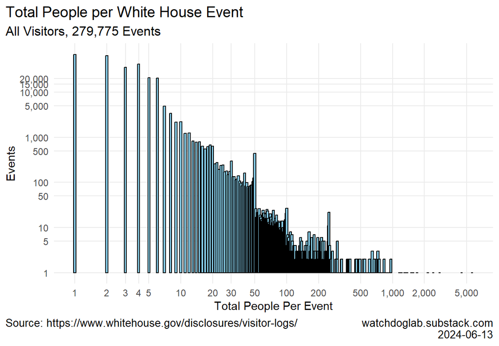

```r
ggplot(eventCountsByGroup, aes(x = `Total People`, y= Events))  +
  geom_bar(stat = "identity",
           fill = COLOR_BAR,  color = "black", width = 0.02)    +
  scale_x_log10(breaks = c(1:5, 10, 20, 30, 50,
                           100, 200, 500, 1000, 2000, 5000),
                labels = scales::comma)                         +
  scale_y_log10(breaks = c(1, 5, 10, 50, 100, 500,
                           1000, 5000, 10000, 15000, 20000),
                labels = scales::comma)                         +
  labs(
        title    = "Total People per White House Event",
        subtitle = paste0("All Visitors, ", paste(comma(nrow(events)), "Events")),
        x = "Total People Per Event",
        y = "Events",
        caption = c(SOURCE, stamp)
      )
```

## 4.2 POTUS Events

Not sure why, but x-axis scaling is not very dynamic unless filtered to only GROUP of interest.

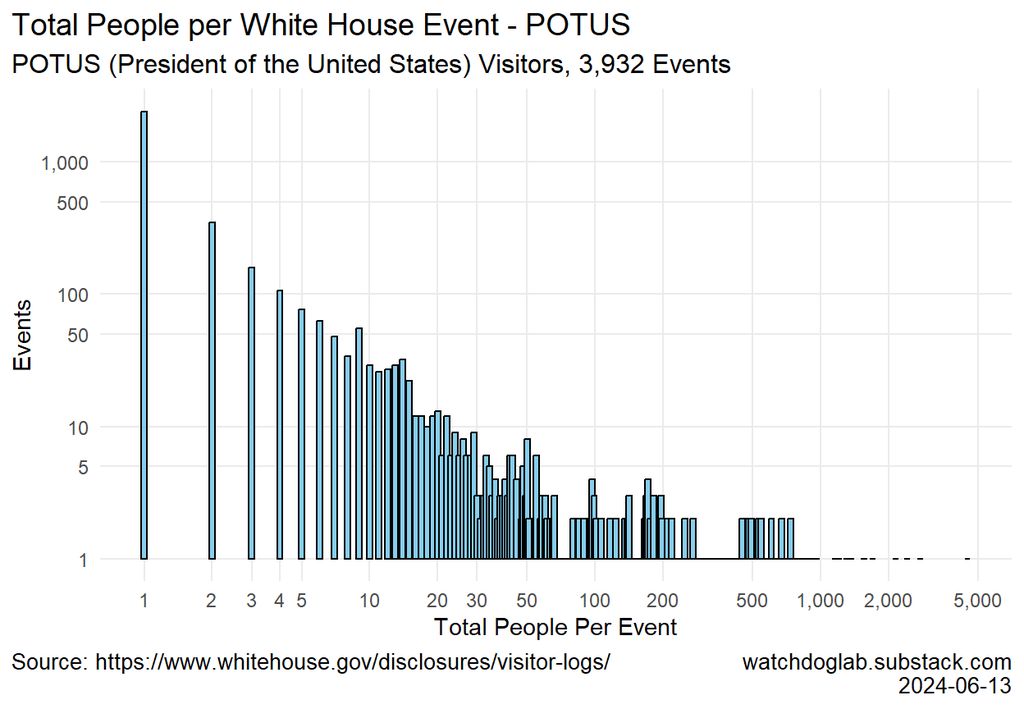

```r
eventCountsByGroup               |>
  select(`Total People`, POTUS)  |>
  filter(POTUS > 0)              |>
ggplot(aes(x = `Total People`, y= POTUS))                             +
  geom_bar(stat = "identity",
           fill = COLOR_BAR,  color = "black", width = 0.025)         +
  scale_x_log10(breaks = c(1:5, 10, 20, 30, 50,
                           100, 200, 500, 1000, 2000, 5000),
                labels = scales::comma)                               +
  scale_y_log10(breaks = c(1, 5, 10, 50, 100, 500,
                           1000, 5000, 10000, 15000, 20000),
                labels = scales::comma)                               +
  labs(
        title    = "Total People per White House Event - POTUS",
        subtitle = paste0("POTUS (President of the United States) Visitors, ",
                          comma(sum(eventCountsByGroup$POTUS)), " Events"),
        x = "Total People Per Event",
        y = "Events",
        caption = c(SOURCE, stamp)
      )
```

## 4.3 VPOTUS Events

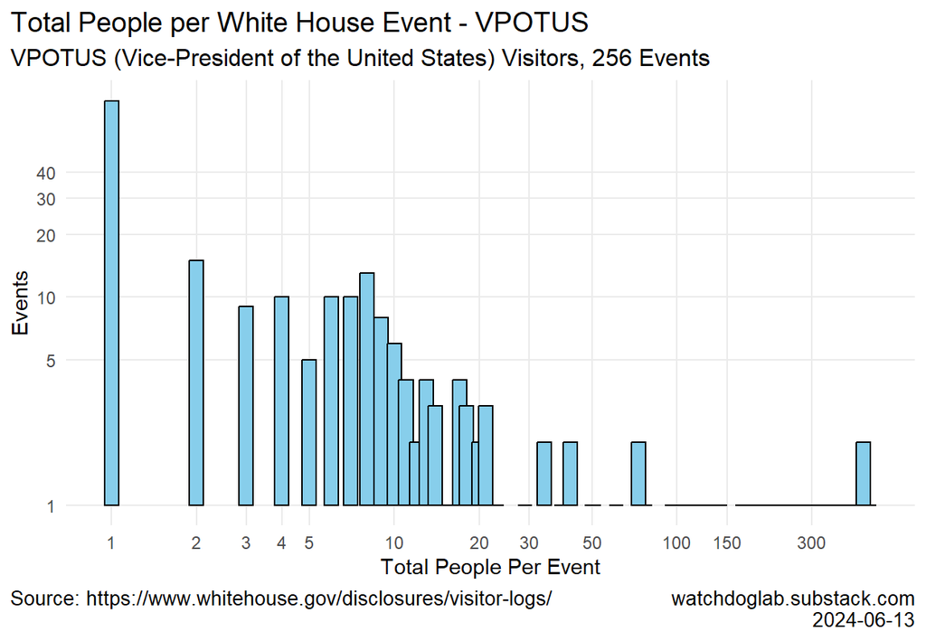

```r
eventCountsByGroup               |>
  select(`Total People`, VPOTUS) |>
  filter(VPOTUS > 0)             |>
ggplot(aes(x = `Total People`, y= VPOTUS))                            +
  geom_bar(stat = "identity",
           fill = COLOR_BAR, color = "black", width = 0.05)           +
  scale_x_log10(breaks = c(1:5, 10, 20, 30, 50,
                           100, 150, 300),
                labels = scales::comma)                               +
  scale_y_log10(breaks = c(1, 5, 10, 20, 30, 40),
                labels = scales::comma)                               +
  labs(
        title    = "Total People per White House Event - VPOTUS",
        subtitle = paste0("VPOTUS (Vice-President of the United States) Visitors, ",
                          comma(sum(eventCountsByGroup$VPOTUS)), " Events"),
        x = "Total People Per Event",
        y = "Events",
        caption = c(SOURCE, stamp)
      )
```

## 4.4 FLOTUS Events

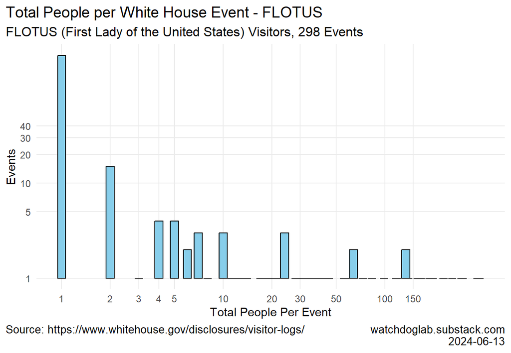

```r
eventCountsByGroup                |>
  select(`Total People`, FLOTUS)  |>
  filter(FLOTUS > 0)              |>
ggplot(aes(x = `Total People`, y= FLOTUS))                            +
  geom_bar(stat = "identity",
           fill = COLOR_BAR, color = "black", width = 0.05)           +
  scale_x_log10(breaks = c(1:5, 10, 20, 30, 50,
                           100, 150),
                labels = scales::comma)                               +
  scale_y_log10(breaks = c(1, 5, 10, 20, 30, 40),
                labels = scales::comma)                               +
  labs(
        title    = "Total People per White House Event - FLOTUS",
         subtitle = paste0("FLOTUS (First Lady of the United States) Visitors, ",
                          comma(sum(eventCountsByGroup$FLOTUS)), " Events"),
        x = "Total People Per Event",
        y = "Events",
        caption = c(SOURCE, stamp)
      )
```

## 4.5 Staff Events

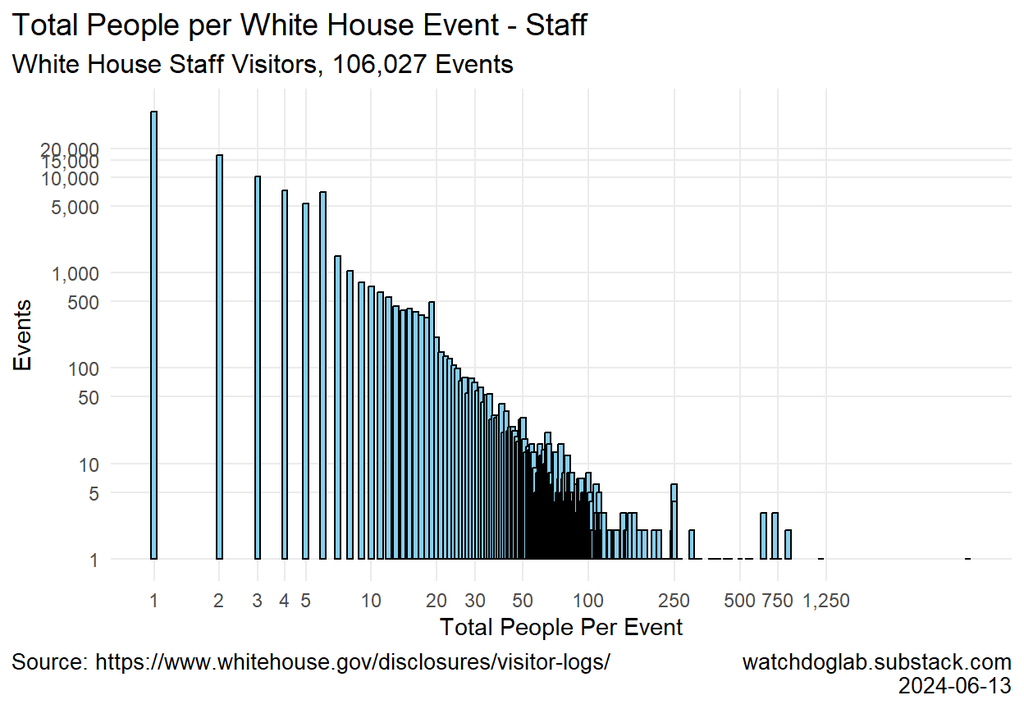

```r
eventCountsByGroup               |>
  select(`Total People`, Staff)  |>
  filter(Staff > 0)              |>
ggplot(aes(x = `Total People`, y= Staff))                             +
  geom_bar(stat = "identity",
           fill = COLOR_BAR,  color = "black", width = 0.025)         +
  scale_x_log10(breaks = c(1:5, 10, 20, 30, 50,
                           100, 250, 500, 750, 1250),
                labels = scales::comma)                               +
  scale_y_log10(breaks = c(1, 5, 10, 50, 100, 500,
                           1000, 5000, 10000, 15000, 20000),
                labels = scales::comma)                               +
  labs(
        title    = "Total People per White House Event - Staff",
        subtitle = paste0("White House Staff Visitors, ",
                          comma(sum(eventCountsByGroup$Staff)), " Events"),
        x = "Total People Per Event",
        y = "Events",
        caption = c(SOURCE, stamp)
      )
```

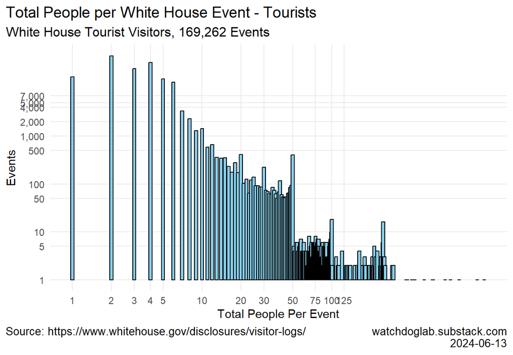

```r
eventCountsByGroup                 |>
  select(`Total People`, Tourist)  |>
  filter(Tourist > 0)              |>
ggplot(aes(x = `Total People`, y= Tourist))                           +
  geom_bar(stat = "identity",
           fill = COLOR_BAR,  color = "black", width = 0.025)         +
  scale_x_log10(breaks = c(1:5, 10, 20, 30, 50, 75, 100, 125),
                labels = scales::comma)                               +
  scale_y_log10(breaks = c(1, 5, 10, 50, 100, 500,
                           1000, 2000, 4000, 5000, 7000),
                labels = scales::comma)                               +
  labs(
        title    = "Total People per White House Event - Tourists",
        subtitle = paste0("White House Tourist Visitors, ",
                          comma(sum(eventCountsByGroup$Tourist)), " Events"),
        x = "Total People Per Event",
        y = "Events",
        caption = c(SOURCE, stamp)
      )
```

# 5 Event Start Date Hour

Next time: use function for the Hour plots

## 5.1 Overall

Most of the Hour = 0 values are caused by missing time fields with date-only values.

```r
hourCounts <-
  events         |>
  group_by(Hour) |>
  count()

nrow(hourCounts)
```

```
[1] 25
```

```r
sum(hourCounts$n)
```

```
[1] 279775
```

Would like to use `coord_polar`for 24-hour clock here but it is fickle or has bugs.

Oddly, must expand left x-limit or first bar is clipped when present – this as also a problem with `coord_polar`

```r
hourCountsLessMissing <-
  hourCounts  |>
  filter(Hour != 0)

sum(hourCountsLessMissing$n)
```

```
[1] 264881
```

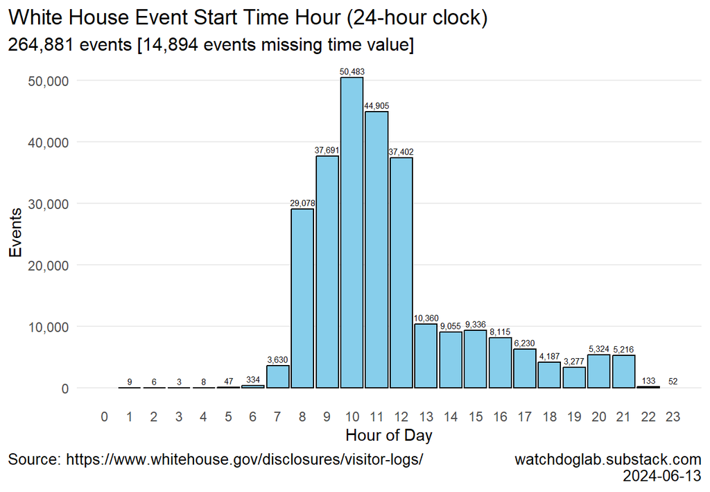

```r
ggplot(hourCountsLessMissing)          +
  geom_bar(aes(x = Hour, y = n),
           stat = "identity",
           fill = COLOR_BAR,  color = "black")               +

  scale_x_continuous(limits = c(0, 23),
                     breaks = seq(0, 23))                    +
  scale_y_continuous(labels = scales::comma)                 +

  geom_text(aes(x = Hour, y = n, label = comma(n)),
            vjust = -0.5, hjust = 0.5, size = 2, angle = 0) +

  labs(title = "White House Event Start Time Hour (24-hour clock)",
       subtitle = paste0(comma(sum(hourCountsLessMissing$n)), " events [",
                         comma(sum(hourCounts$n) -
                               sum(hourCountsLessMissing$n)),
                         " events missing time value]"),
       x = "Hour of Day",
       y = "Events",
       caption = c(SOURCE, stamp))                           +
  theme(panel.grid.major.x    = element_blank())
```

## 5.2 By Group

```r
hourCountsByGroup <-
  events                                         |>
  group_by(GROUP)                                |>
  count()

hourCountsByGroup |> Show(height = "200px")
```

| GROUP | n |
| --- | --- |
| POTUS | 3932 |
| VPOTUS | 256 |
| FLOTUS | 298 |
| Staff | 106027 |
| Tourist | 169262 |

```r
hourCountsByGroupYear <-
  events                                            |>
  mutate(Year = substr(APPT_START_DATE,  1,  4)  |>
                as.numeric(),
         Hour = substr(APPT_START_DATE, 12, 13)  |>
                as.numeric())                        |>
  group_by(GROUP, Year)                             |>
  count(Hour)

hourCountsByGroupYear |> Show(height = "200px")
```

| GROUP | Year | Hour | n |
| --- | --- | --- | --- |
| POTUS | 2021 | 5 | 1 |
| POTUS | 2021 | 6 | 1 |
| POTUS | 2021 | 8 | 1 |
| POTUS | 2021 | 9 | 8 |
| POTUS | 2021 | 10 | 13 |
| POTUS | 2021 | 11 | 1 |
| POTUS | 2021 | 12 | 13 |
| POTUS | 2021 | 13 | 16 |
| POTUS | 2021 | 14 | 11 |
| POTUS | 2021 | 15 | 5 |
| POTUS | 2021 | 16 | 6 |
| POTUS | 2021 | 17 | 3 |
| POTUS | 2021 | 18 | 2 |
| POTUS | 2021 | NA | 384 |
| POTUS | 2022 | 6 | 2 |
| POTUS | 2022 | 7 | 8 |
| POTUS | 2022 | 8 | 31 |
| POTUS | 2022 | 9 | 78 |
| POTUS | 2022 | 10 | 118 |
| POTUS | 2022 | 11 | 51 |
| POTUS | 2022 | 12 | 58 |
| POTUS | 2022 | 13 | 79 |
| POTUS | 2022 | 14 | 142 |
| POTUS | 2022 | 15 | 116 |
| POTUS | 2022 | 16 | 103 |
| POTUS | 2022 | 17 | 64 |
| POTUS | 2022 | 18 | 167 |
| POTUS | 2022 | 19 | 159 |
| POTUS | 2022 | 20 | 64 |
| POTUS | 2022 | 21 | 2 |

[output cut: 240 more lines]

```r
write_xlsx(hourCountsByGroupYear,
           paste0("White-House-Event-Start-Hour-by-Group-",
                  DATA_RELEASE, ".xlsx"))
```

### 5.2.1 POTUS

```r
hourCounts <-
  events                   |>
  filter(GROUP == "POTUS") |>
  group_by(Hour)           |>
  count()

nrow(hourCounts)
```

```
[1] 18
```

```r
sum(hourCounts$n)
```

```
[1] 3932
```

```r
hourCountsLessMissing <-
  hourCounts  |>
  filter(Hour != 0)

sum(hourCountsLessMissing$n)
```

```
[1] 3281
```

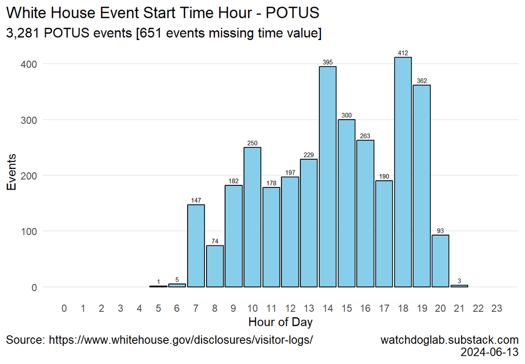

```r
ggplot(hourCountsLessMissing)          +
  geom_bar(aes(x = Hour, y = n),
           stat = "identity",
           fill = COLOR_BAR,  color = "black")               +

   scale_x_continuous(limits = c(0, 23),
                     breaks = seq(0, 23))                    +
  scale_y_continuous(labels = scales::comma)                 +

  geom_text(aes(x = Hour, y = n, label = comma(n)),
            vjust = -0.5, hjust = 0.5, size = 2, angle = 0) +

  labs(title = "White House Event Start Time Hour - POTUS",
       subtitle = paste0(comma(sum(hourCountsLessMissing$n)), " POTUS events [",
                         comma(sum(hourCounts$n) -
                               sum(hourCountsLessMissing$n)),
                         " events missing time value]"),
       x = "Hour of Day",
       y = "Events",
       caption = c(SOURCE, stamp))                           +
  theme(panel.grid.major.x    = element_blank())
```

### 5.2.2 VPOTUS

```r
hourCounts <-
  events                    |>
  filter(GROUP == "VPOTUS") |>
  group_by(Hour)            |>
  count()

nrow(hourCounts)
```

```
[1] 16
```

```r
sum(hourCounts$n)
```

```
[1] 256
```

```r
hourCountsLessMissing <-
  hourCounts  |>
  filter(Hour != 0)

sum(hourCountsLessMissing$n)
```

```
[1] 223
```

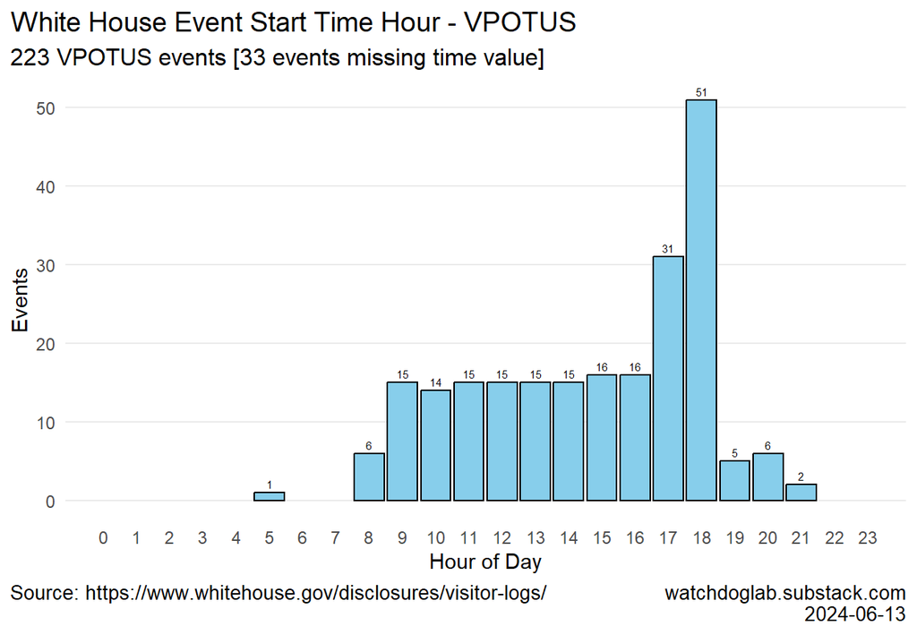

```r
ggplot(hourCountsLessMissing)          +
  geom_bar(aes(x = Hour, y = n),
           stat = "identity",
           fill = COLOR_BAR,  color = "black")               +

  scale_x_continuous(limits = c(0, 23),
                     breaks = seq(0, 23))                    +
  scale_y_continuous(labels = scales::comma)                 +

  geom_text(aes(x = Hour, y = n, label = comma(n)),
            vjust = -0.5, hjust = 0.5, size = 2, angle = 0) +

  labs(title = "White House Event Start Time Hour - VPOTUS",
       subtitle = paste0(comma(sum(hourCountsLessMissing$n)), " VPOTUS events [",
                         comma(sum(hourCounts$n) -
                               sum(hourCountsLessMissing$n)),
                         " events missing time value]"),
       x = "Hour of Day",
       y = "Events",
       caption = c(SOURCE, stamp))                           +
  theme(panel.grid.major.x    = element_blank())
```

### 5.2.3 FLOTUS

```r
hourCounts <-
  events                    |>
  filter(GROUP == "FLOTUS") |>
  group_by(Hour)            |>
  count()

nrow(hourCounts)
```

```
[1] 13
```

```r
sum(hourCounts$n)
```

```
[1] 298
```

```r
hourCountsLessMissing <-
  hourCounts  |>
  filter(Hour != 0)

sum(hourCountsLessMissing$n)
```

```
[1] 263
```

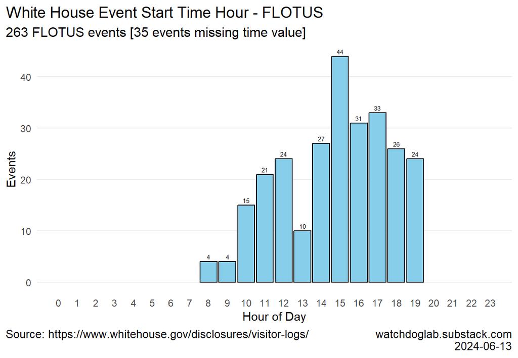

```r
ggplot(hourCountsLessMissing)          +
  geom_bar(aes(x = Hour, y = n),
           stat = "identity",
           fill = COLOR_BAR,  color = "black")               +

  scale_x_continuous(limits = c(0, 23),
                     breaks = seq(0, 23))                    +
  scale_y_continuous(labels = scales::comma)                 +

  geom_text(aes(x = Hour, y = n, label = comma(n)),
            vjust = -0.5, hjust = 0.5, size = 2, angle = 0) +

  labs(title = "White House Event Start Time Hour - FLOTUS",
       subtitle = paste0(comma(sum(hourCountsLessMissing$n)), " FLOTUS events [",
                         comma(sum(hourCounts$n) -
                               sum(hourCountsLessMissing$n)),
                         " events missing time value]"),
       x = "Hour of Day",
       y = "Events",
       caption = c(SOURCE, stamp))                           +
  theme(panel.grid.major.x    = element_blank())
```

### 5.2.4 Staff

```r
hourCounts <-
  events                   |>
  filter(GROUP == "Staff") |>
  group_by(Hour)           |>
  count()

nrow(hourCounts)
```

```
[1] 25
```

```r
sum(hourCounts$n)
```

```
[1] 106027
```

```r
hourCountsLessMissing <-
  hourCounts  |>
  filter(Hour != 0)

sum(hourCountsLessMissing$n)
```

```
[1] 93279
```

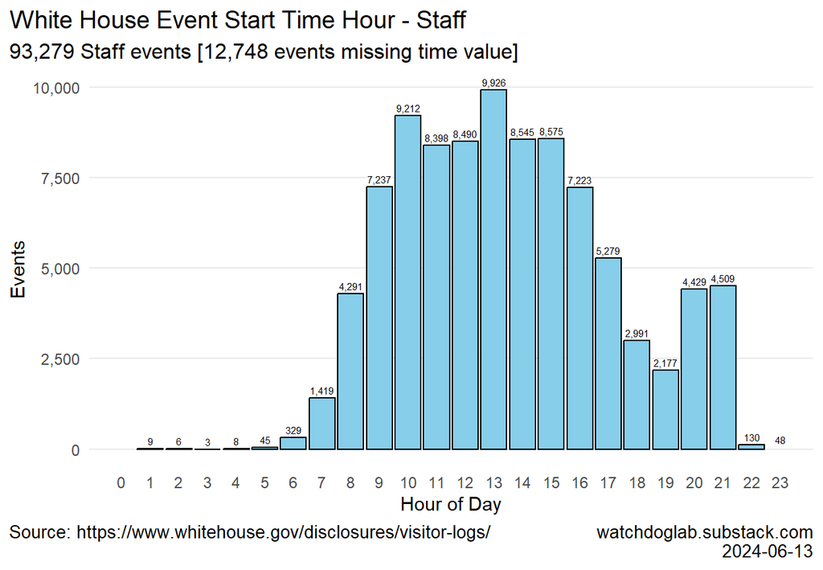

```r
ggplot(hourCountsLessMissing)          +
  geom_bar(aes(x = Hour, y = n),
           stat = "identity",
           fill = COLOR_BAR,  color = "black")               +

  scale_x_continuous(limits = c(0, 23),
                     breaks = seq(0, 23))                    +
  scale_y_continuous(labels = scales::comma)                 +

  geom_text(aes(x = Hour, y = n, label = comma(n)),
            vjust = -0.5, hjust = 0.5, size = 2, angle = 0) +

  labs(title = "White House Event Start Time Hour - Staff",
       subtitle = paste0(comma(sum(hourCountsLessMissing$n)), " Staff events [",
                         comma(sum(hourCounts$n) -
                               sum(hourCountsLessMissing$n)),
                         " events missing time value]"),
       x = "Hour of Day",
       y = "Events",
       caption = c(SOURCE, stamp))                           +
  theme(panel.grid.major.x    = element_blank())
```

### 5.2.5 Tourist

```r
hourCounts <-
  events                     |>
  filter(GROUP == "Tourist") |>
  group_by(Hour)             |>
  count()

nrow(hourCounts)
```

```
[1] 18
```

```r
sum(hourCounts$n)
```

```
[1] 169262
```

```r
hourCountsLessMissing <-
  hourCounts  |>
  filter(Hour != 0)

sum(hourCountsLessMissing$n)
```

```
[1] 167835
```

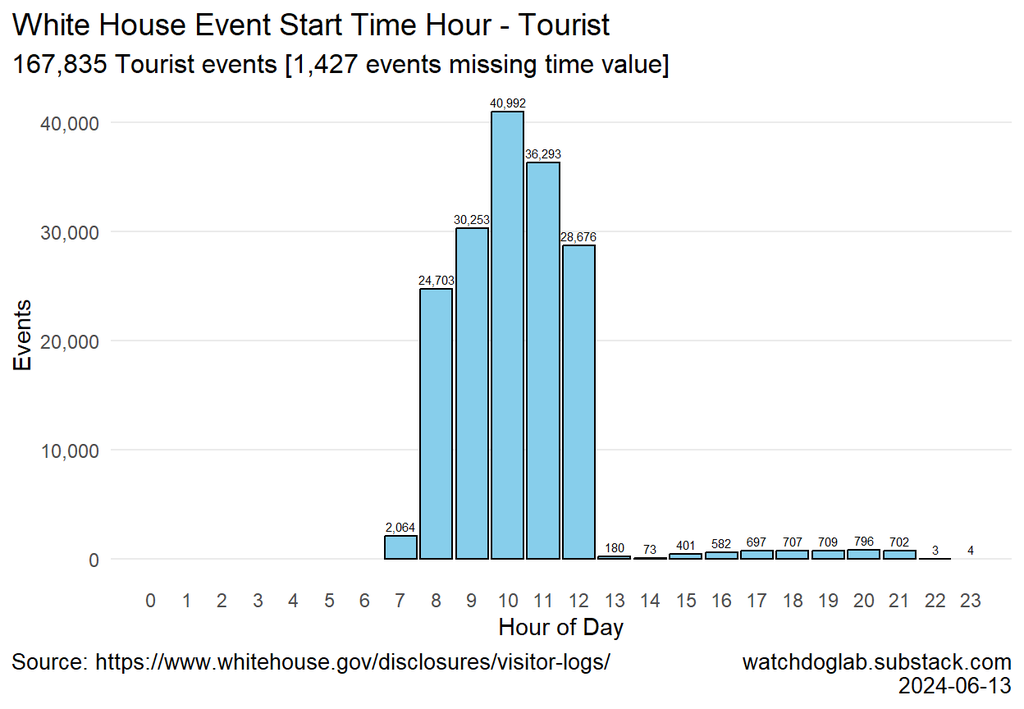

```r
ggplot(hourCountsLessMissing)          +
  geom_bar(aes(x = Hour, y = n),
           stat = "identity",
           fill = COLOR_BAR,  color = "black")               +

  scale_x_continuous(limits = c(0, 23),
                     breaks = seq(0, 23))                    +
  scale_y_continuous(labels = scales::comma)                 +

  geom_text(aes(x = Hour, y = n, label = comma(n)),
            vjust = -0.5, hjust = 0.5, size = 2, angle = 0) +

  labs(title = "White House Event Start Time Hour - Tourist",
       subtitle = paste0(comma(sum(hourCountsLessMissing$n)), " Tourist events [",
                         comma(sum(hourCounts$n) -
                               sum(hourCountsLessMissing$n)),
                         " events missing time value]"),
       x = "Hour of Day",
       y = "Events",
       caption = c(SOURCE, stamp))                           +
  theme(panel.grid.major.x    = element_blank())
```

### 5.2.6 After-Hour Tourists

```r
afterHourTouristEvents <-
  events                     |>
  filter(GROUP == "Tourist",
         Hour  >= 15)        |>
  select(Event)              |>
  unique()

nrow(afterHourTouristEvents)
```

```
[1] 4596
```

```r
afterHourTourists <-
  wh   |>
  inner_join(afterHourTouristEvents, by = "Event") %>%
  arrange(APPT_START_DATE, VISITEE, VISITOR)

nrow(afterHourTourists)
```

```
[1] 98019
```

```r
write_xlsx(afterHourTourists,
           paste0("White-House-After-Hours-Tourists-",
                  DATA_RELEASE, ".xlsx"))
```

## 5.3 Hour by Month

```r
hourCountsByGroupYearMonth <-
  events                                          |>
  mutate(Year  = substr(APPT_START_DATE,  1,  4),
         Month = substr(APPT_START_DATE,  6,  7),
         Hour  = substr(APPT_START_DATE, 12, 13)) |>
  group_by(GROUP, Year, Month, Hour)              |>
  count()                                         |>
  arrange(Year, Month, Hour, GROUP)

hourCountsByGroupYearMonth |> Show(height = "200px")
```

| GROUP | Year | Month | Hour | n |
| --- | --- | --- | --- | --- |
| Staff | 2021 | 01 | 06 | 1 |
| Staff | 2021 | 01 | 07 | 7 |
| Staff | 2021 | 01 | 08 | 14 |
| Staff | 2021 | 01 | 09 | 37 |
| POTUS | 2021 | 01 | 10 | 1 |
| Staff | 2021 | 01 | 10 | 23 |
| POTUS | 2021 | 01 | 11 | 1 |
| Staff | 2021 | 01 | 11 | 14 |
| Staff | 2021 | 01 | 12 | 18 |
| Staff | 2021 | 01 | 13 | 15 |
| Staff | 2021 | 01 | 14 | 11 |
| Staff | 2021 | 01 | 15 | 8 |
| Staff | 2021 | 01 | 16 | 6 |
| Staff | 2021 | 01 | 17 | 2 |
| Staff | 2021 | 01 | 20 | 2 |
| Staff | 2021 | 01 | 21 | 1 |
| Tourist | 2021 | 01 | 23 | 1 |
| Staff | 2021 | 02 |  | 2 |
| Staff | 2021 | 02 | 06 | 7 |
| Staff | 2021 | 02 | 07 | 6 |
| Staff | 2021 | 02 | 08 | 45 |
| POTUS | 2021 | 02 | 09 | 4 |
| FLOTUS | 2021 | 02 | 09 | 1 |
| Staff | 2021 | 02 | 09 | 70 |
| POTUS | 2021 | 02 | 10 | 3 |
| Staff | 2021 | 02 | 10 | 86 |
| Staff | 2021 | 02 | 11 | 58 |
| POTUS | 2021 | 02 | 12 | 4 |
| FLOTUS | 2021 | 02 | 12 | 1 |
| Staff | 2021 | 02 | 12 | 79 |

[output cut: 1295 more lines]

```r
write_xlsx(hourCountsByGroupYearMonth,
           paste0("White-House-Event-Start-Hour-by-Group-Month-",
                  DATA_RELEASE, ".xlsx"))
```

# 6 Visitors by Month

```r
byMonth <-
  wh                            |>
  mutate(APPT_MONTH = substr(APPT_START_DATE,  1, 7))  |>   # YYYY-MM

  group_by(APPT_MONTH, GROUP)   |>
  count()                       |>
  ungroup()                     |>

  spread(GROUP, n, fill = 0) |>
  mutate(
          Visitors           = rowSums(across(POTUS:Tourist)),
          PVF                = POTUS + VPOTUS + FLOTUS,
          Month              = paste0(APPT_MONTH, "-01") |> ymd()
        )                    |>
  relocate(Month)

dim(byMonth)
```

```
[1] 38  9
```

```r
byMonth |> Show(bigMark = ",", height = "300px")
```

| Month | APPT_MONTH | POTUS | VPOTUS | FLOTUS | Staff | Tourist | Visitors | PVF |
| --- | --- | --- | --- | --- | --- | --- | --- | --- |
| 2021-01-01 | 2021-01 | 7 | 0 | 0 | 391 | 2 | 400 | 7 |
| 2021-02-01 | 2021-02 | 88 | 0 | 2 | 974 | 0 | 1,064 | 90 |
| 2021-03-01 | 2021-03 | 103 | 3 | 0 | 1,168 | 0 | 1,274 | 106 |
| 2021-04-01 | 2021-04 | 159 | 17 | 0 | 1,333 | 0 | 1,509 | 176 |
| 2021-05-01 | 2021-05 | 217 | 11 | 0 | 1,514 | 0 | 1,742 | 228 |
| 2021-06-01 | 2021-06 | 262 | 11 | 0 | 1,881 | 0 | 2,154 | 273 |
| 2021-07-01 | 2021-07 | 1,805 | 10 | 0 | 3,790 | 0 | 5,605 | 1,815 |
| 2021-08-01 | 2021-08 | 345 | 0 | 0 | 1,733 | 0 | 2,078 | 345 |
| 2021-09-01 | 2021-09 | 204 | 53 | 0 | 2,401 | 0 | 2,658 | 257 |
| 2021-10-01 | 2021-10 | 259 | 19 | 132 | 2,442 | 0 | 2,852 | 410 |
| 2021-11-01 | 2021-11 | 1,290 | 16 | 130 | 3,167 | 0 | 4,603 | 1,436 |
| 2021-12-01 | 2021-12 | 662 | 4 | 5 | 4,966 | 9,829 | 15,466 | 671 |
| 2022-01-01 | 2022-01 | 117 | 0 | 18 | 1,048 | 1 | 1,184 | 135 |
| 2022-02-01 | 2022-02 | 200 | 8 | 26 | 1,920 | 1 | 2,155 | 234 |
| 2022-03-01 | 2022-03 | 1,383 | 21 | 38 | 4,621 | 0 | 6,063 | 1,442 |
| 2022-04-01 | 2022-04 | 1,941 | 0 | 107 | 6,852 | 4,619 | 13,519 | 2,048 |
| 2022-05-01 | 2022-05 | 4,035 | 6 | 138 | 8,054 | 7,866 | 20,099 | 4,179 |
| 2022-06-01 | 2022-06 | 915 | 852 | 280 | 7,191 | 8,158 | 17,396 | 2,047 |
| 2022-07-01 | 2022-07 | 9,162 | 24 | 35 | 13,952 | 16,587 | 39,760 | 9,221 |
| 2022-08-01 | 2022-08 | 1,062 | 8 | 0 | 10,003 | 19,962 | 31,035 | 1,070 |
| 2022-09-01 | 2022-09 | 8,248 | 42 | 60 | 13,697 | 15,207 | 37,254 | 8,350 |
| 2022-10-01 | 2022-10 | 1,306 | 0 | 80 | 15,617 | 22,274 | 39,277 | 1,386 |
| 2022-11-01 | 2022-11 | 608 | 0 | 854 | 14,796 | 11,671 | 27,929 | 1,462 |
| 2022-12-01 | 2022-12 | 15,860 | 1,154 | 3 | 25,595 | 44,406 | 87,018 | 17,017 |
| 2023-01-01 | 2023-01 | 1,523 | 18 | 0 | 13,219 | 19,949 | 34,709 | 1,541 |
| 2023-02-01 | 2023-02 | 1,054 | 519 | 31 | 15,254 | 28,685 | 45,543 | 1,604 |
| 2023-03-01 | 2023-03 | 2,621 | 225 | 37 | 20,230 | 46,521 | 69,634 | 2,883 |
| 2023-04-01 | 2023-04 | 8,099 | 440 | 8 | 23,338 | 37,856 | 69,741 | 8,547 |
| 2023-05-01 | 2023-05 | 2,691 | 527 | 4 | 19,826 | 60,242 | 83,290 | 3,222 |
| 2023-06-01 | 2023-06 | 8,112 | 339 | 0 | 31,109 | 55,324 | 94,884 | 8,451 |
| 2023-07-01 | 2023-07 | 2,846 | 300 | 209 | 25,599 | 55,820 | 84,774 | 3,355 |
| 2023-08-01 | 2023-08 | 924 | 449 | 190 | 12,496 | 30,200 | 44,259 | 1,563 |
| 2023-09-01 | 2023-09 | 933 | 814 | 358 | 20,975 | 47,145 | 70,225 | 2,105 |
| 2023-10-01 | 2023-10 | 2,043 | 32 | 776 | 23,285 | 57,131 | 83,267 | 2,851 |
| 2023-11-01 | 2023-11 | 2,443 | 404 | 681 | 17,922 | 18,406 | 39,856 | 3,528 |
| 2023-12-01 | 2023-12 | 14,090 | 5,561 | 56 | 17,783 | 84,490 | 121,980 | 19,707 |
| 2024-01-01 | 2024-01 | 317 | 241 | 101 | 14,991 | 32,948 | 48,598 | 659 |
| 2024-02-01 | 2024-02 | 781 | 277 | 184 | 19,954 | 31,502 | 52,698 | 1,242 |

```r
write_xlsx(byMonth,
           paste0("White-House-Visitors-by-Month-Table-",
                  DATA_RELEASE, ".xlsx"))
```

```r
longFormat <-
  byMonth                 |>
  select(-APPT_MONTH)     |>
  pivot_longer(
                cols      = c("POTUS", "VPOTUS", "FLOTUS",
                              "Staff", "Tourist",
                              "Visitors", "PVF"),
                names_to  = "Group",
                values_to = "Visits"
               )

dim(longFormat)
```

```
[1] 266   3
```

Will need to filter for Groups of interest in any plot since there is double counting.

```r
longFormat |> head(10) |> Show()
```

| Month | Group | Visits |
| --- | --- | --- |
| 2021-01-01 | POTUS | 7 |
| 2021-01-01 | VPOTUS | 0 |
| 2021-01-01 | FLOTUS | 0 |
| 2021-01-01 | Staff | 391 |
| 2021-01-01 | Tourist | 2 |
| 2021-01-01 | Visitors | 400 |
| 2021-01-01 | PVF | 7 |
| 2021-02-01 | POTUS | 88 |
| 2021-02-01 | VPOTUS | 0 |
| 2021-02-01 | FLOTUS | 2 |

## 6.1 PVL = POTUS + VPOTUS + FLOTUS

Use default blue color for POTUS, but two different sets of qualitative pairs for plots below.

```r
POTUS_COLOR <- "#619CFF"
set2 <- brewer.pal( 8, "Set2")  # Brewer qualitative palettes
set3 <- brewer.pal(12, "Set3")
```

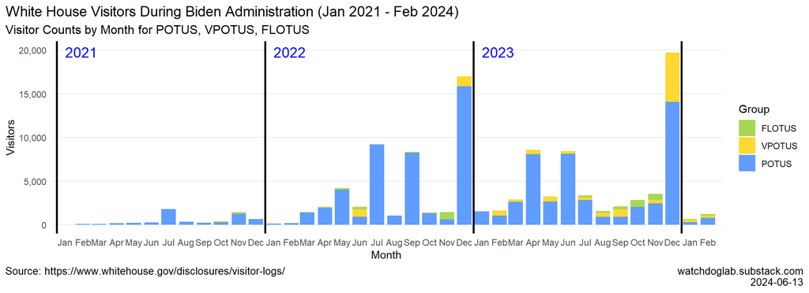

```r
longFormat                                                               |>
  filter(Group %in% c("POTUS", "VPOTUS", "FLOTUS"))                      |>
  mutate(Group = factor(Group, levels = c("FLOTUS", "VPOTUS", "POTUS"))) |>
  ggplot(aes(x = Month, y = Visits, fill = Group))     +
  geom_bar(position = "stack", stat = "identity")      +
  scale_y_continuous(
                      labels = scales::comma,
                      limits = c(0, PVF_LIMIT),
                  #    breaks = 5000 * 0:4
                    )                                  +
  scale_x_date(
                date_breaks = "1 month",
                expand = c(0.01, 0),
                labels = date_format("%b")
              )                                        +

  geom_vline(xintercept = c(
                             as.Date("2020-12-17"),
                             as.Date("2021-12-17"),
                             as.Date("2022-12-17"),
                             as.Date("2023-12-17")
                            ),
             color = "black", size = 1,
             linetype = "solid")                       +
  annotate("text",
           x = c(
                  as.Date("2021-01-01"),
                  as.Date("2022-01-01"),
                  as.Date("2023-01-01"),
                  as.Date("2024-01-01")
                 ),
           y = Inf,
           label = c("2021", "2022", "2023", ""),
           color = "blue",
           hjust = 0, vjust = 1.5,
           size  = 5)                                  +

                             # FLOTUS    VPOTUS    POTUS
  scale_fill_manual(values = c(set2[5],  set2[6],  POTUS_COLOR))  +

  labs(
        title    = paste0("White House Visitors During Biden Administration ", RANGE),
        subtitle = "Visitor Counts by Month for POTUS, VPOTUS, FLOTUS",
        x = "Month",
        y = "Visitors",
        caption = c(SOURCE, stamp)
      )                                                +
  theme(panel.grid.major.x    = element_blank(),
        legend.position = "right")
```

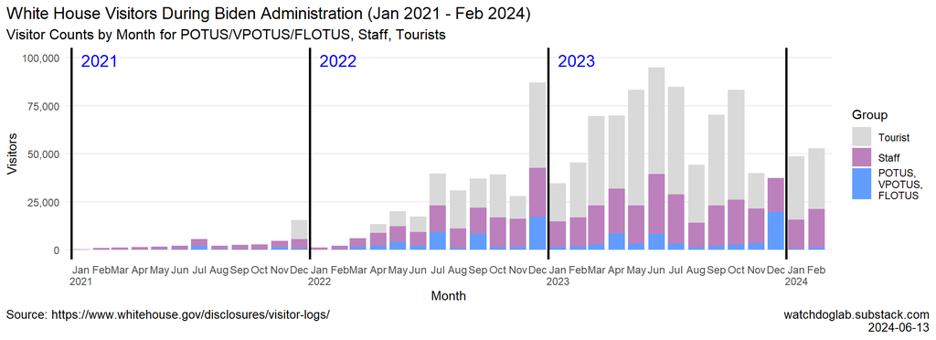

```r
longFormat                                                             |>
  filter(Group %in% c("PVF", "Staff", "Tourist"))                      |>
  mutate(Group = factor(Group, levels = c("Tourist", "Staff", "PVF"))) |>
  ggplot(aes(x = Month, y = Visits, fill = Group))  +
  geom_bar(position = "stack", stat = "identity")   +

  scale_y_continuous(labels = scales::comma,
                     limits = c(0, VISITOR_LIMIT))  +
  scale_x_date(
                date_breaks = "1 month",
                expand = c(0.01, 0),
                labels = date_format(c("%b",  # terrible kludge here
                                       "%b\n%Y",
                                       rep("%b", 10)))
              )                                     +

  geom_vline(xintercept = c(
                             as.Date("2020-12-17"),
                             as.Date("2021-12-17"),
                             as.Date("2022-12-17"),
                             as.Date("2023-12-17")
                           ),
             color = "black", size = 1,
             linetype = "solid")                    +

  annotate("text",
           x = c(
                  as.Date("2021-01-01"),
                  as.Date("2022-01-01"),
                  as.Date("2023-01-01"),
                  as.Date("2024-01-01")
                ),
           y = Inf,
           label = c("2021", "2022", "2023", ""),
           color = "blue",
           hjust = 0, vjust = 1.5,
           size  = 5)                               +


   scale_fill_manual(values=c(set3[9],  set3[10], POTUS_COLOR),
                    labels = c("Tourist", "Staff", "POTUS,\nVPOTUS,\nFLOTUS"))  +

  labs(
        title    = paste0("White House Visitors During Biden Administration ", RANGE),
        subtitle = "Visitor Counts by Month for POTUS/VPOTUS/FLOTUS, Staff, Tourists",
        x = "Month",
        y = "Visitors",
        caption = c(SOURCE, stamp)
      )                                             +
  theme(panel.grid.major.x    = element_blank(),
        legend.position = "right")
```

# 7 Epilog

## 7.1

Processing time: 38.4 secs

2024-06-13 2317